# Group Shape Differences & the general lineal model

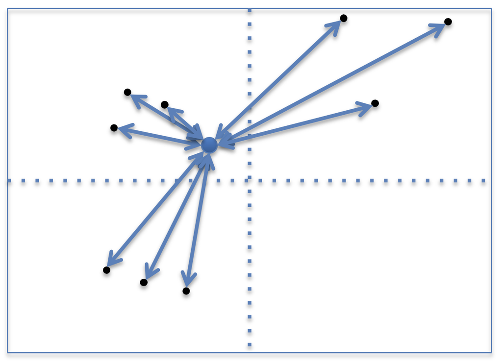

Additional info (for those interested)

Antigoni Kaliontzopoulou, Universitat de Barcelona

01 June, 2026

# Some more details on:

- Geometric interpretation of model effects
- Multiple model effects
- Types of Sums of Squares

# Geometric Interpretation of Model Effects

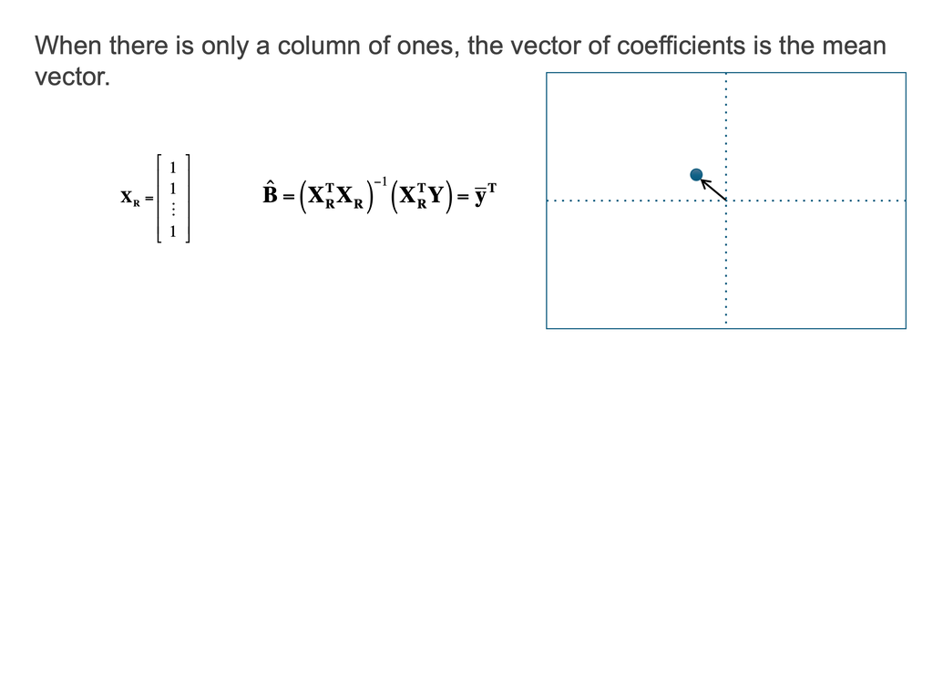

# Geometric Interpretation of Model Effects (cont.)

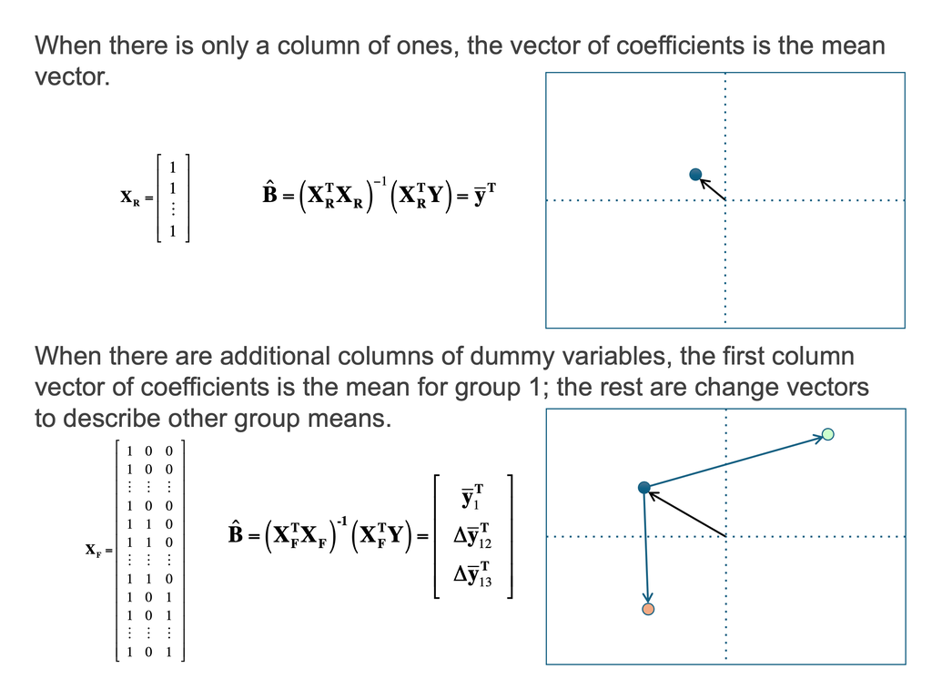

# Geometric Interpretation of Model Effects (cont.)

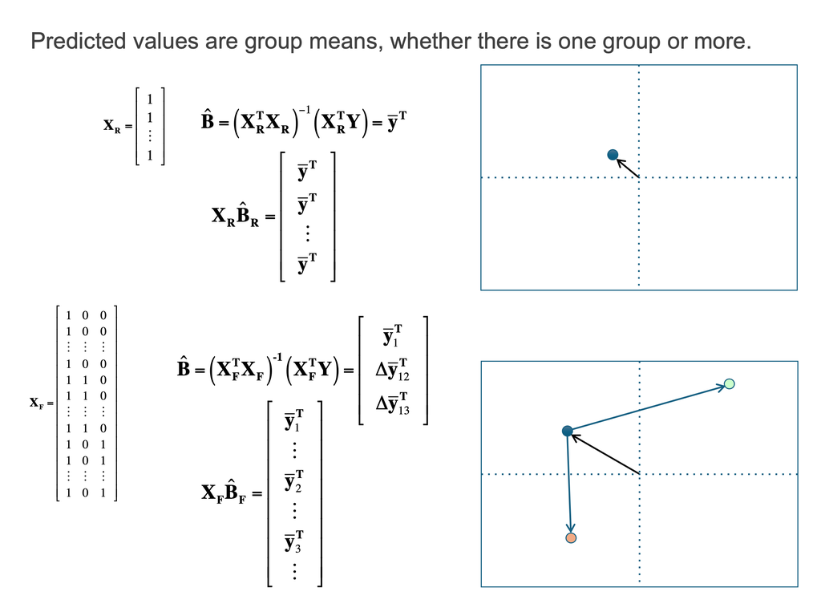

# Geometric Interpretation of Model Effects (cont.)

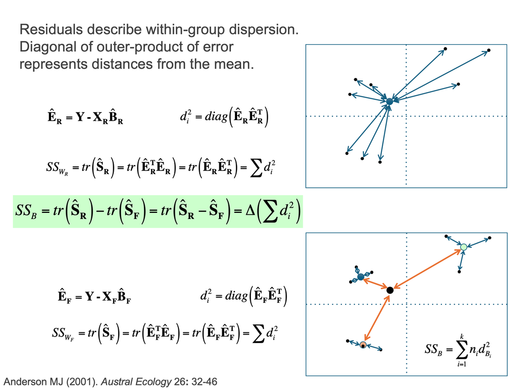

# Multiple Model Effects

It might be apparent with the pupfish example, or any other example with which one might familiar, that there is often more than a null model and a full model.  
There might be different **effects** that could be considered for different sets of parameters.  
In the pupfish example, we might ask whether $Sex$ or $Population$ contribute more to the dispersion in means. We might also wonder if the $Sex$ effect varies between populations.

Not to worry! The model comparison approach can be done in sequence for different model effects. There are only a few little twists with which to be concerned.

#### Preliminaries:

1. Let **null** refer to the model with only an intercept and whose purpose is to estimate an overall mean.
2. Let **reduced** refer to a model with limited parameters, which serves as a basis for comparison.
3. Let **full** refer to a model with all parameters of the reduced model, plus parameters for an effect of interest.

In the initial pupfish example, the null and reduced models were the same; the full model had parameters to estimate four group means. We are going to use the same model now to consider partial effects associated with the dispersion of the four means.

# Multiple Model Effects (Type I SS)

In the pupfish example, we could have the following set of model comparisons to estimate different effects

| Effect | Reduced | Full | Purpose |
| --- | --- | --- | --- |
| Sex | Null | Null + Sex | Determine if Sex mean difference is “significant” compared to an overall mean |
| Pop | Null + Sex | Null + Sex + Pop | Determine if population differences are significant, after accounting for general difference between males and females |
| Sex:Pop | Null + Sex + Pop | Null + Sex + Pop + Sex:Pop | Determine if sexual dimorphism varies between populations, after accounting for general difference in sex and population. |
| Full model | Null | Null + Sex + Pop + Sex:Pop | Ascertain if the model is significant (if not, the other parts should not be considered significant either) |

Estimating $SS$ between models for the first three model comparisons is called **Sequential (Type I) $SS$** estimation. We start with a null model and build up to the fullest model.

# Multiple Model Effects (Type II SS)

In the pupfish example, we could have the following set of model comparisons to estimate different effects

| Effect | Reduced | Full | Purpose |
| --- | --- | --- | --- |
| Sex | Null + Pop | Null + Pop + Sex | Determine if Sex mean difference is “significant”, after accounting for population mean difference |
| Pop | Null + Sex | Null + Sex + Pop | Determine if population differences are significant, after accounting for general difference between males and females |
| Sex:Pop | Null + Sex + Pop | Null + Sex + Pop + Sex:Pop | Determine if sexual dimorphism varies between populations, after accounting for general difference in sex and population. |
| Full model | Null | Null + Sex + Pop + Sex:Pop | Ascertain if the model is signficant (if not, the other parts should not be considered significant either) |

Estimating $SS$ between models for the first three model comparisons is called **Conditional (Type II) $SS$** estimation. We analyze effects with respect to other effects, but do not include interactions with targeted effects. For example, with three factors, A, B, and C. The effect A would have a reduced model of B, C, and B:C. The full model would add A to these. The effect A:B, would have a reduced model of A, B, C, and B:C, and the full model would add A:B to these.

# Multiple Model Effects (Type III SS)

In the pupfish example, we could have the following set of model comparisons to estimate different effects

| Effect | Reduced | Full | Purpose |
| --- | --- | --- | --- |
| Sex | Null + Pop + Pop:Sex | Null + Pop + Sex + Pop:Sex | Determine if Sex mean difference is “significant”, after accounting for all other effects |
| Pop | Null + Sex + Pop:Sex | Null + Sex + Pop + Pop:Sex | Determine if population differences are significant, after accounting for all other effects. |
| Sex:Pop | Null + Sex + Pop | Null + Sex + Pop + Sex:Pop | Determine if sexual dimorphism varies between populations, after accounting for general difference in sex and population. |
| Full model | Null | Null + Sex + Pop + Sex:Pop | Ascertain if the model is signficant (if not, the other parts should not be considered significant either) |

Estimating $SS$ between models for the first three model comparisons is called **Marginal (Type III) $SS$** estimation. Whereas Type I $SS$ evaluates the importance of effects through inclusion, Type III $SS$ evaluates the importance of effects through exclusion.

# Example: Types of SS

```r
fit1 <- procD.lm(coords ~ Pop * Sex, data = pupfish, iter = 999, SS.type = "I", print.progress = FALSE)
fit2 <- procD.lm(coords ~ Pop * Sex, data = pupfish, iter = 999, SS.type = "II", print.progress = FALSE)
fit3 <- procD.lm(coords ~ Pop * Sex, data = pupfish, iter = 999, SS.type = "III", print.progress = FALSE)

anova(fit1)
```

```
##
## Analysis of Variance, using Residual Randomization
## Permutation procedure: Randomization of null model residuals
## Number of permutations: 1000
## Estimation method: Ordinary Least Squares
## Sums of Squares and Cross-products: Type I
## Effect sizes (Z) based on F distributions
##
##           Df       SS        MS     Rsq      F      Z Pr(>F)
## Pop        1 0.008993 0.0089927 0.15964 16.076 3.9997  0.001 ***
## Sex        1 0.015917 0.0159169 0.28255 28.453 4.1103  0.001 ***
## Pop:Sex    1 0.003453 0.0034532 0.06130  6.173 3.7015  0.001 ***
## Residuals 50 0.027970 0.0005594 0.49651
## Total     53 0.056333
## ---
## Signif. codes:  0 '***' 0.001 '**' 0.01 '*' 0.05 '.' 0.1 ' ' 1
##
## Call: procD.lm(f1 = coords ~ Pop * Sex, iter = 999, SS.type = "I",
##     data = pupfish, print.progress = FALSE)
```

```r
anova(fit2)
```

```
##
## Analysis of Variance, using Residual Randomization
## Permutation procedure: Randomization of null model residuals
## Number of permutations: 1000
## Estimation method: Ordinary Least Squares
## Sums of Squares and Cross-products: Type II
## Effect sizes (Z) based on F distributions
##
##           Df       SS        MS     Rsq      F      Z Pr(>F)
## Pop        1 0.009129 0.0091294 0.16206 16.320 4.7097  0.001 ***
## Sex        1 0.015917 0.0159169 0.28255 28.453 4.1103  0.001 ***
## Pop:Sex    1 0.003453 0.0034532 0.06130  6.173 3.7015  0.001 ***
## Residuals 50 0.027970 0.0005594 0.49651
## Total     53 0.056333
## ---
## Signif. codes:  0 '***' 0.001 '**' 0.01 '*' 0.05 '.' 0.1 ' ' 1
##
## Call: procD.lm(f1 = coords ~ Pop * Sex, iter = 999, SS.type = "II",
##     data = pupfish, print.progress = FALSE)
```

```r
anova(fit3)
```

```
##
## Analysis of Variance, using Residual Randomization
## Permutation procedure: Randomization of null model residuals
## Number of permutations: 1000
## Estimation method: Ordinary Least Squares
## Sums of Squares and Cross-products: Type III
## Effect sizes (Z) based on F distributions
##
##           Df       SS        MS     Rsq      F      Z Pr(>F)
## Pop        1 0.007479 0.0074790 0.13276 13.370 4.7007  0.001 ***
## Sex        1 0.015253 0.0152534 0.27077 27.267 4.5358  0.001 ***
## Pop:Sex    1 0.003453 0.0034532 0.06130  6.173 3.7015  0.001 ***
## Residuals 50 0.027970 0.0005594 0.49651
## Total     53 0.056333
## ---
## Signif. codes:  0 '***' 0.001 '**' 0.01 '*' 0.05 '.' 0.1 ' ' 1
##
## Call: procD.lm(f1 = coords ~ Pop * Sex, iter = 999, SS.type = "III",
##     data = pupfish, print.progress = FALSE)
```

# Multiple Model Effects (comments)